# Ophiocoma von Mises modelling

John Kirwan

11/4/2019

Analyses to test whether observations of angular data are oriented towards stimuli, according to a von Mises distribution.

```r
options(mc.cores = parallel::detectCores())
library('circular')
library('tibble')
library('readr')
library('tidyr')
library('dplyr')
library('ggplot2')
library('rstan')
rstan_options(auto_write = TRUE)
Sys.setenv(LOCAL_CPPFLAGS = '-march=native')
library('brms')
sumlength <- function (x) { round(100* sum(x<0) / length(x),1) }
```

The requisite part of pre-modelling markdown document is condensed below.

```r
df <- read_delim('Ophiocoma_orientation_data.txt',delim = "\t")
df <- subset.data.frame(df, Relative_heading_degrees != "DNF")
df$heading <- as.numeric(df$Relative_heading_degrees)*pi/180
df$heading[df$heading > pi] <- -pi +(df$heading[df$heading > pi] -pi)
df$Species <- as.factor(df$Species)
df$Type    <- as.factor(df$Type)
df$Set     <- as.factor(df$Set)
df <- subset.data.frame(df, select = -c(Absolute_heading_degrees,Relative_heading_degrees))
df %>% filter(Set == 2017) -> df2017
df2017 <- droplevels.data.frame(df2017)
df %>% filter(Set == 2019) -> df2019
df2019 <- droplevels.data.frame(df2019)
```

## “Null” model

To examine to what extent clustering occurs we can first run a model which looks at the observations but does not consider the species, giving a grand mean across the trials. The code below sets the model formula.

```r
Mises_1_intercept.formula <- bf(heading ~ 0, kappa ~ 1, family = von_mises(link='tan_half'))
Mises_1_intercept.data    <- make_standata(heading ~ 1, kappa ~ 1,
                                  data = df2017, family = von_mises(link='tan_half'))
```

## Priors

To pick a suitable prior for the kappa value, we can look at different parameterizations of the gamma / lognormal distributions to use a positive bounded prior for kappa (concentration). The idea is to pick a reasonable range for the probability mass, without weighting it to heavily in either direction. The prior ideally ought to be *weakly informative*, giving little informationto influence the posterior, except to converge models and avoid nonsensical values. The priors are positive as they relate to kappa, rather than log(kappa).

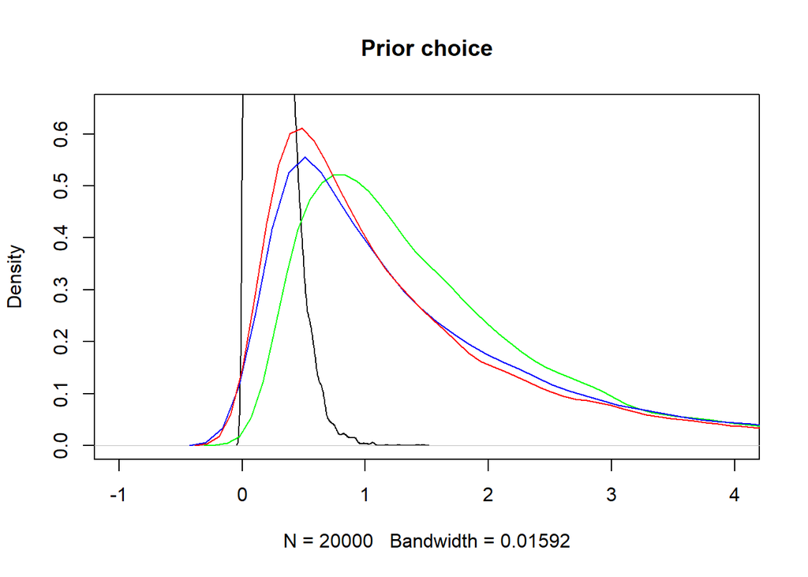

# Try replacing kappa intercept lognormal(0.1,1) later with something that doesn’t penalise v low kappa, e.g. gamma(1,2)

The code below fits the model. The prior of lognormal(0.25, 0.75) is to guide it away from 0 to allow it converge.

```r
Mises_1_intercept.prior = c(prior(lognormal(0.25, 0.75),  class = Intercept, dpar="kappa"))

Mises_1_intercept.fit <- brm( Mises_1_intercept.formula,
  prior = Mises_1_intercept.prior, iter = 20000,
  data = df2017, chains = 4,
  control = list(adapt_delta = 0.9999))
Mises_1_intercept.fit <- add_criterion(Mises_1_intercept.fit, c("loo","waic"))
summary(Mises_1_intercept.fit)
```

```
##  Family: von_mises
##   Links: mu = tan_half; kappa = log
## Formula: heading ~ 0
##          kappa ~ 1
##    Data: df2017 (Number of observations: 269)
## Samples: 4 chains, each with iter = 20000; warmup = 10000; thin = 1;
##          total post-warmup samples = 40000
##
## Population-Level Effects:
##                 Estimate Est.Error l-95% CI u-95% CI Rhat Bulk_ESS
## kappa_Intercept     0.06      0.02     0.03     0.10 1.00     7581
##                 Tail_ESS
## kappa_Intercept     7788
##
## Samples were drawn using sampling(NUTS). For each parameter, Eff.Sample
## is a crude measure of effective sample size, and Rhat is the potential
## scale reduction factor on split chains (at convergence, Rhat = 1).
```

Rhats of 1 and an acceptable effective sample size in relation to the total number of obervations. The model converged well. Below is a posterior predictive plot.

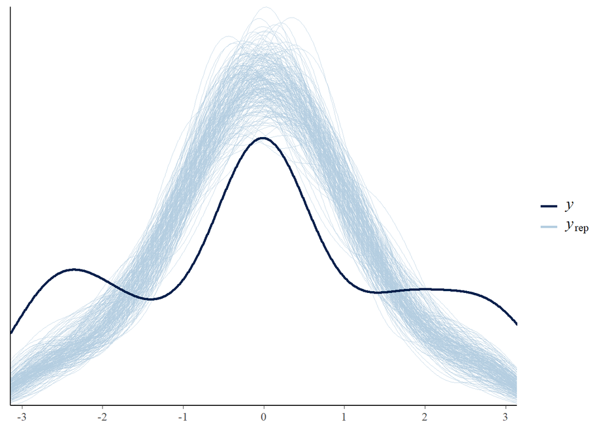

```r
pp_check(Mises_1_intercept.fit, type="dens_overlay", nsamples=200)
```

Plot the posterior distributions and the Markov chains.

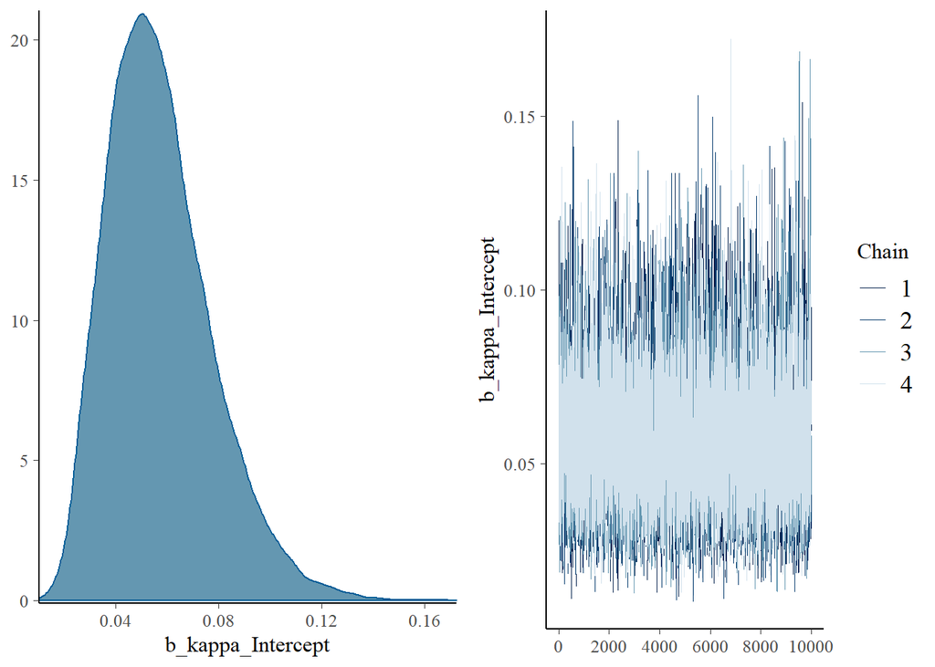

To interpret these, we can extract the values and reverse the log-link.

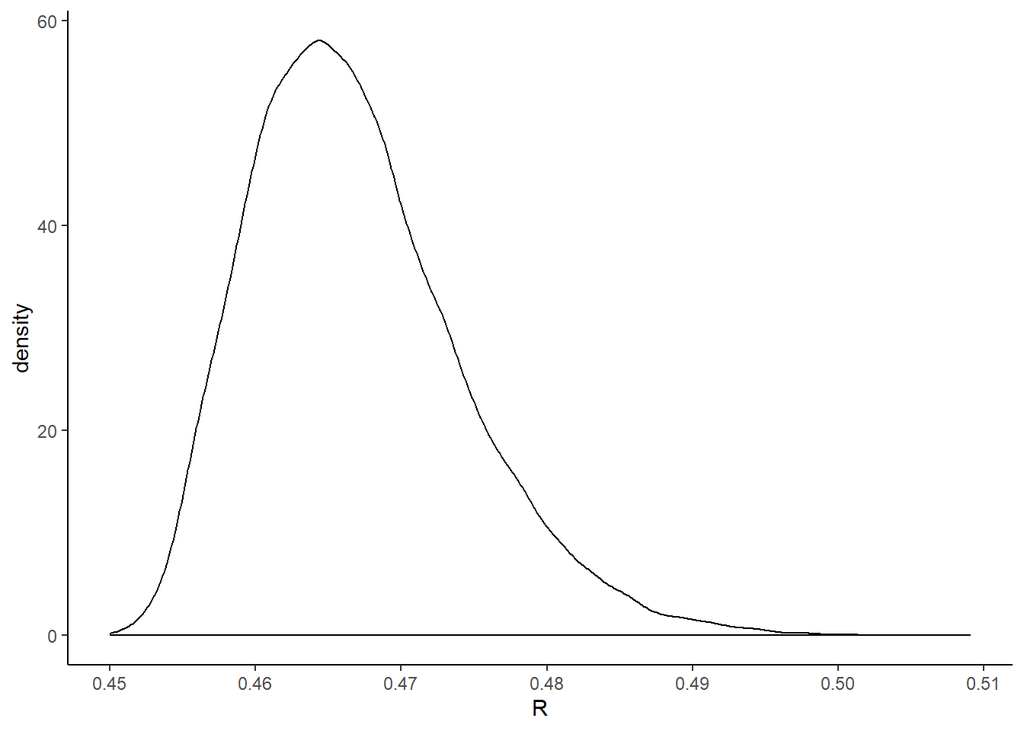

And here is one with a dummy variable included to distinguish the signal types but still without species considered.

Plot the posterior probabilities by parameter and the Markov chains.

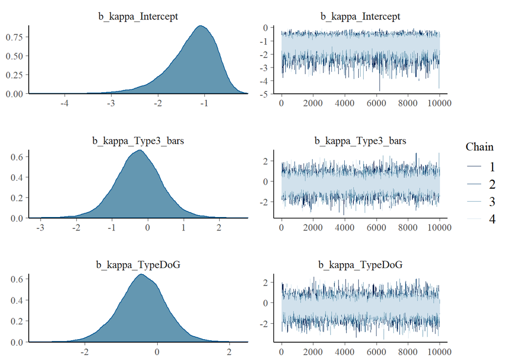

```r
plot(Mises_Type.fit,ask=F)
```

Unimodal posterior distributions with well converged Markov chains.

```r
summary(Mises_Type.fit)
```

```
##  Family: von_mises
##   Links: mu = tan_half; kappa = log
## Formula: heading ~ 0
##          kappa ~ Type
##    Data: df2017 (Number of observations: 269)
## Samples: 4 chains, each with iter = 20000; warmup = 10000; thin = 1;
##          total post-warmup samples = 40000
##
## Population-Level Effects:
##                  Estimate Est.Error l-95% CI u-95% CI Rhat Bulk_ESS
## kappa_Intercept     -1.27      0.51    -2.49    -0.50 1.00    23465
## kappa_Type3_bars    -0.26      0.64    -1.55     1.02 1.00    22270
## kappa_TypeDoG       -0.42      0.67    -1.77     0.87 1.00    23012
##                  Tail_ESS
## kappa_Intercept     16866
## kappa_Type3_bars    20586
## kappa_TypeDoG       22131
##
## Samples were drawn using sampling(NUTS). For each parameter, Eff.Sample
## is a crude measure of effective sample size, and Rhat is the potential
## scale reduction factor on split chains (at convergence, Rhat = 1).
```

ESS and Rhat values are good. Below is a graphical check of the marginal effects at the median.

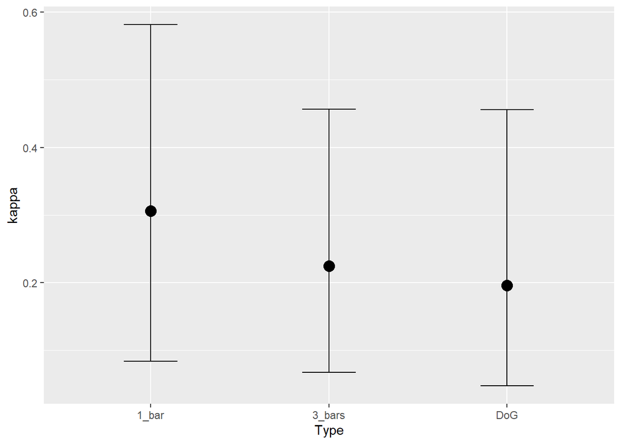

```r
marginal_effects(Mises_Type.fit, method = "fitted",dpar = "kappa",
                 resolution = 1000, robust = TRUE,
                 theme=theme_classic(), nsamples = 1000, scale='response',
                                  re_formula = NULL,ask=F)
```

Posterior predictive check.

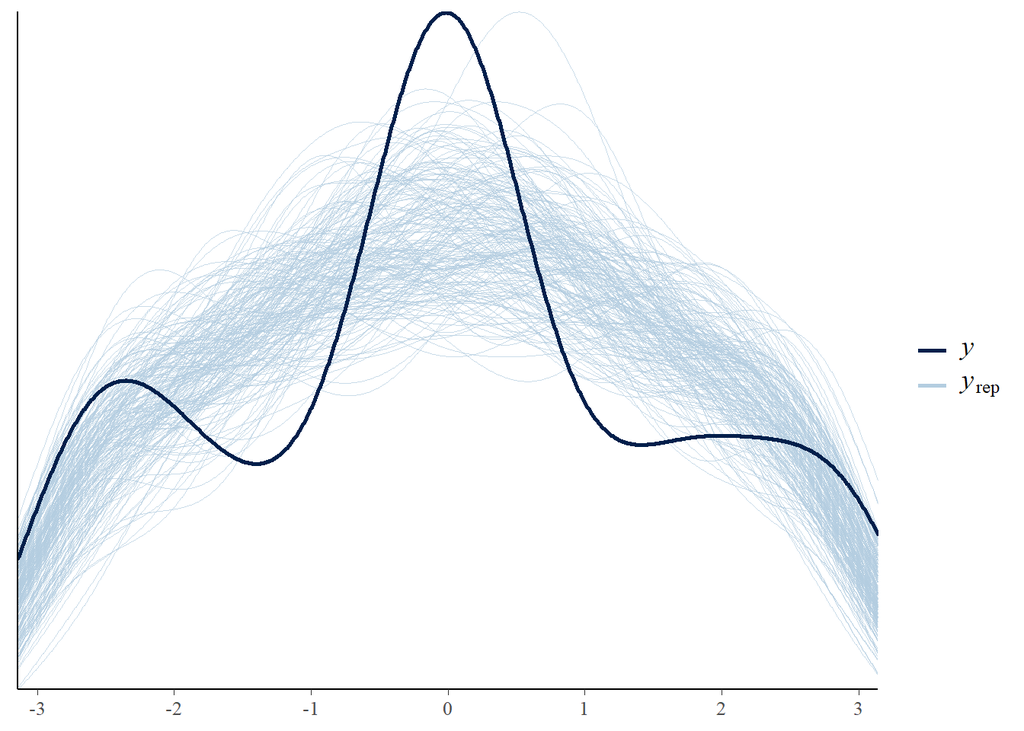

```r
pp_check(Mises_Type.fit, type="dens_overlay", nsamples=200)
```

We can implement a model which divvies it up by species.

```
## recompiling to avoid crashing R session
```

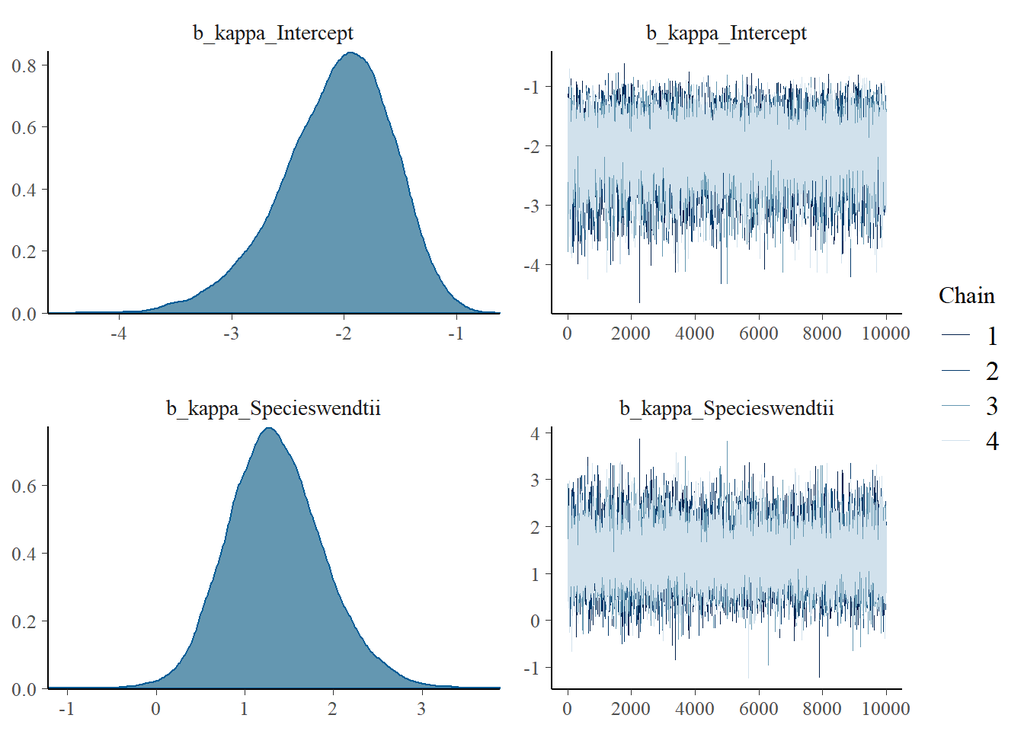

Summary of the von Mises model with the effect of species.

```r
summary(Mises_Spp.fit)
```

```
##  Family: von_mises
##   Links: mu = tan_half; kappa = log
## Formula: heading ~ 0
##          kappa ~ Species
##    Data: df2017 (Number of observations: 269)
## Samples: 4 chains, each with iter = 20000; warmup = 10000; thin = 1;
##          total post-warmup samples = 40000
##
## Population-Level Effects:
##                      Estimate Est.Error l-95% CI u-95% CI Rhat Bulk_ESS
## kappa_Intercept         -2.07      0.49    -3.17    -1.23 1.00    13185
## kappa_Specieswendtii     1.35      0.54     0.37     2.50 1.00    14987
##                      Tail_ESS
## kappa_Intercept         14269
## kappa_Specieswendtii    15937
##
## Samples were drawn using sampling(NUTS). For each parameter, Eff.Sample
## is a crude measure of effective sample size, and Rhat is the potential
## scale reduction factor on split chains (at convergence, Rhat = 1).
```

This converges well. Marginal effects at the median of the von Mises model with the effect of species.

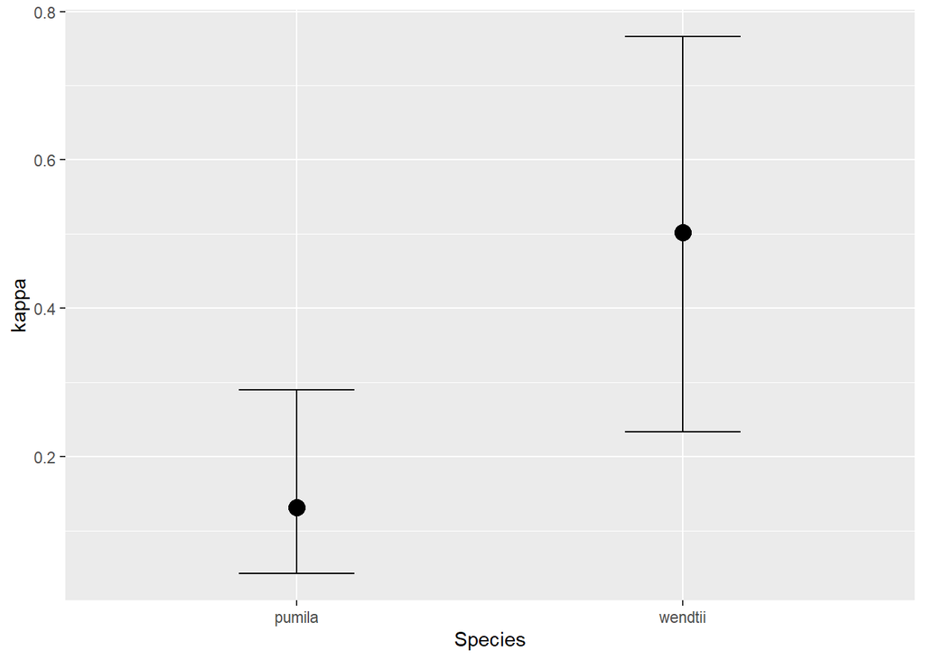

```r
marginal_effects(Mises_Spp.fit,method = "fitted",dpar = "kappa", resolution = 1000, robust = TRUE,
                 theme=theme_classic(), nsamples = 1000, scale='response',
                                  re_formula = NULL,ask=F)
```

Posterior predictive check of the von Mises model with the effect of species.

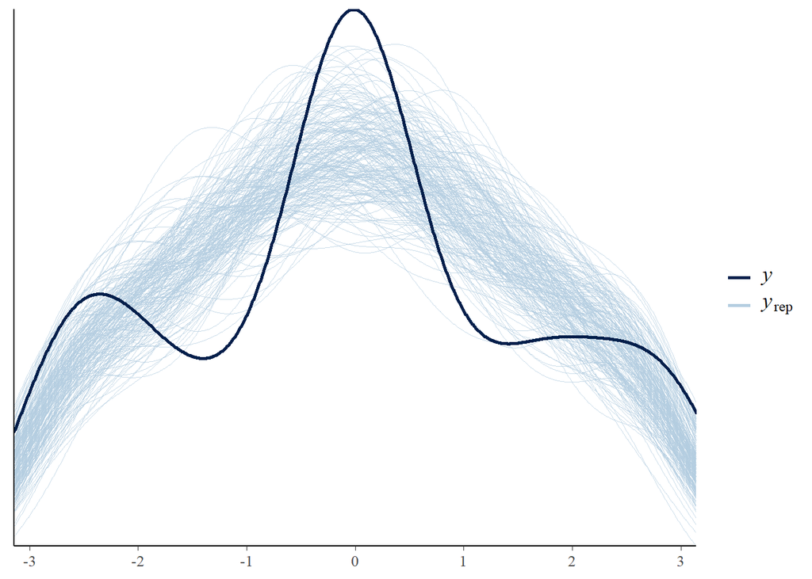

```r
pp_check(Mises_Spp.fit, type="dens_overlay", nsamples=200)
```

Another version with the effects of Type and Species.

```r
Mises_Both.formula <- bf(heading ~ 0, kappa ~ Species + Type, family = von_mises(link='tan_half'))
Mises_Both.data    <- make_standata(heading ~ 1, kappa ~ Species*Type,
                                  data = df2017, family = von_mises(link='tan_half'))

Mises_Both.prior = c( prior(normal(0,1),  class = Intercept, dpar="kappa"),
               prior(normal(0, 1), class = b, dpar="kappa")
             )

Mises_Both.fit <- brm( Mises_Both.formula,
  prior = Mises_Both.prior, iter = 20000,
  data = df2017, chains = 4,
  control = list(adapt_delta = 0.9))
```

```
## recompiling to avoid crashing R session
```

```r
Mises_Both.fit <- add_criterion(Mises_Both.fit, criterion=c("loo","waic"))
```

Model summary.

```r
summary(Mises_Both.fit)
```

```
##  Family: von_mises
##   Links: mu = tan_half; kappa = log
## Formula: heading ~ 0
##          kappa ~ Species + Type
##    Data: df2017 (Number of observations: 269)
## Samples: 4 chains, each with iter = 20000; warmup = 10000; thin = 1;
##          total post-warmup samples = 40000
##
## Population-Level Effects:
##                      Estimate Est.Error l-95% CI u-95% CI Rhat Bulk_ESS
## kappa_Intercept         -1.83      0.55    -3.04    -0.90 1.00    22121
## kappa_Specieswendtii     1.37      0.54     0.38     2.49 1.00    21699
## kappa_Type3_bars        -0.51      0.54    -1.62     0.54 1.00    22720
## kappa_TypeDoG           -0.52      0.55    -1.66     0.52 1.00    23945
##                      Tail_ESS
## kappa_Intercept         19505
## kappa_Specieswendtii    21042
## kappa_Type3_bars        21975
## kappa_TypeDoG           22620
##
## Samples were drawn using sampling(NUTS). For each parameter, Eff.Sample
## is a crude measure of effective sample size, and Rhat is the potential
## scale reduction factor on split chains (at convergence, Rhat = 1).
```

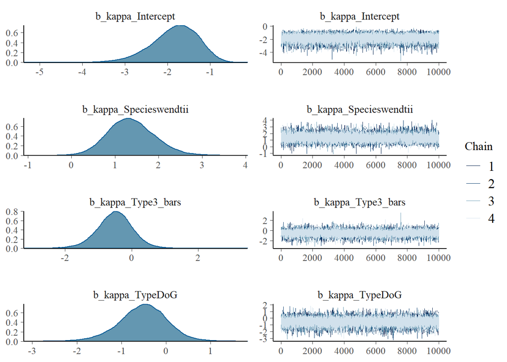

```r
plot(Mises_Both.fit,ask=F)
```

Posterior predictive check.

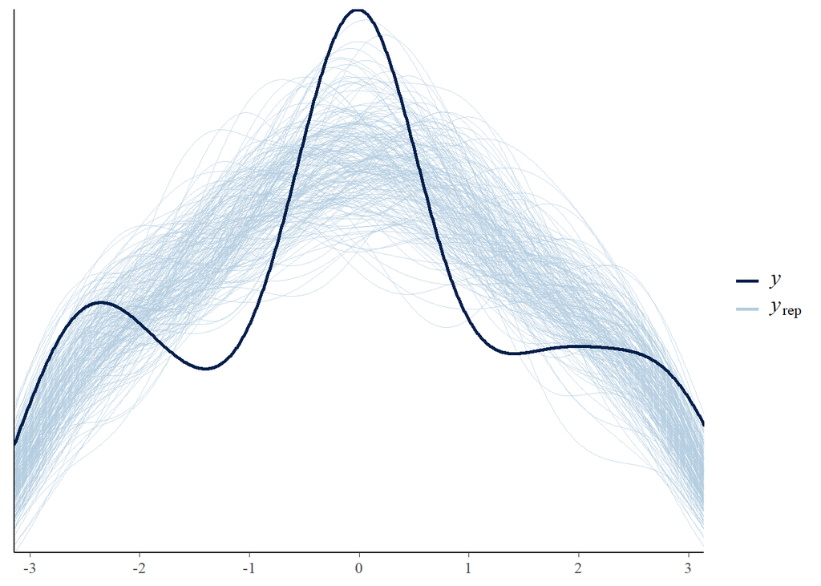

```r
pp_check(Mises_Both.fit, type="dens_overlay", nsamples=200)
```

Marginal effect at the median.

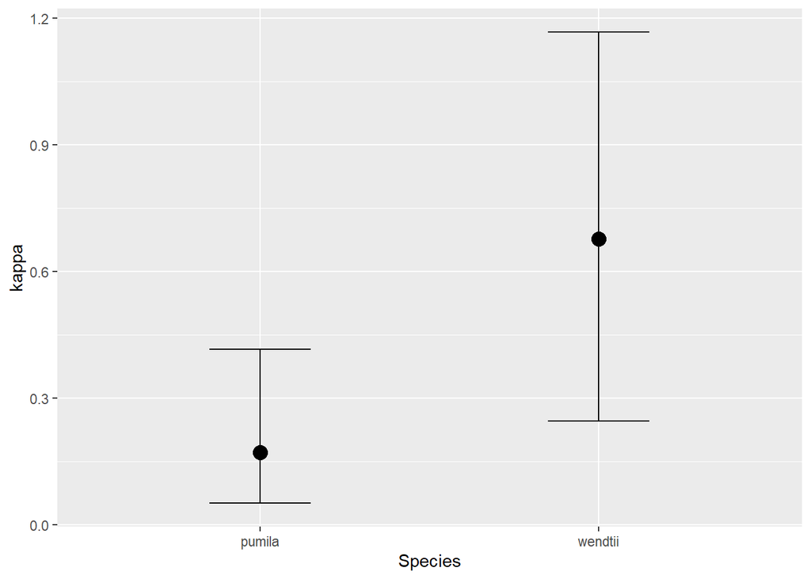

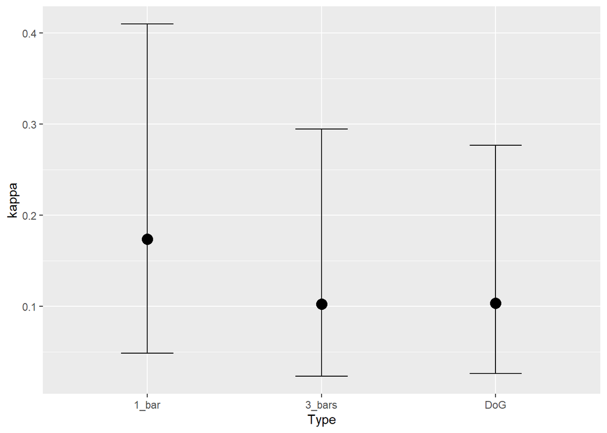

```r
marginal_effects(Mises_Both.fit,method = "fitted",dpar = "kappa", resolution = 1000, robust = TRUE,
                 theme=theme_classic(), nsamples = 1000, scale='response',
                                  re_formula = NULL,ask=F)
```

Further model with both effects and their interaction are included.

```r
Mises_Both_Interaction.formula <- bf(heading ~ 0, kappa ~ Species*Type, family = von_mises(link='tan_half'))
Mises_Both_Interaction.data    <- make_standata(heading ~ 1, kappa ~ Species*Type,
                                  data = df2017, family = von_mises(link='tan_half'))

Mises_Both_Interaction.prior = c( prior(normal(0,1),  class = Intercept, dpar="kappa"),
               prior(normal(0, 1), class = b, dpar="kappa"))

Mises_Both_Interaction.fit <- brm( Mises_Both_Interaction.formula,
  prior = Mises_Both_Interaction.prior, iter = 20000,
  data = df2017, chains = 4,
  control = list(adapt_delta = 0.9))
```

```
## recompiling to avoid crashing R session
```

```r
Mises_Both_Interaction.fit <- add_criterion(Mises_Both_Interaction.fit, criterion=c("loo","waic"))
summary(Mises_Both_Interaction.fit)
```

```
##  Family: von_mises
##   Links: mu = tan_half; kappa = log
## Formula: heading ~ 0
##          kappa ~ Species * Type
##    Data: df2017 (Number of observations: 269)
## Samples: 4 chains, each with iter = 20000; warmup = 10000; thin = 1;
##          total post-warmup samples = 40000
##
## Population-Level Effects:
##                                 Estimate Est.Error l-95% CI u-95% CI Rhat
## kappa_Intercept                    -1.88      0.56    -3.09    -0.93 1.00
## kappa_Specieswendtii                1.43      0.59     0.30     2.64 1.00
## kappa_Type3_bars                   -0.42      0.68    -1.78     0.86 1.00
## kappa_TypeDoG                      -0.52      0.68    -1.89     0.77 1.00
## kappa_Specieswendtii:Type3_bars    -0.21      0.72    -1.64     1.21 1.00
## kappa_Specieswendtii:TypeDoG       -0.09      0.73    -1.55     1.32 1.00
##                                 Bulk_ESS Tail_ESS
## kappa_Intercept                    25255    22717
## kappa_Specieswendtii               22252    24901
## kappa_Type3_bars                   22447    25638
## kappa_TypeDoG                      23753    26667
## kappa_Specieswendtii:Type3_bars    21900    25398
## kappa_Specieswendtii:TypeDoG       22555    24630
##
## Samples were drawn using sampling(NUTS). For each parameter, Eff.Sample
## is a crude measure of effective sample size, and Rhat is the potential
## scale reduction factor on split chains (at convergence, Rhat = 1).
```

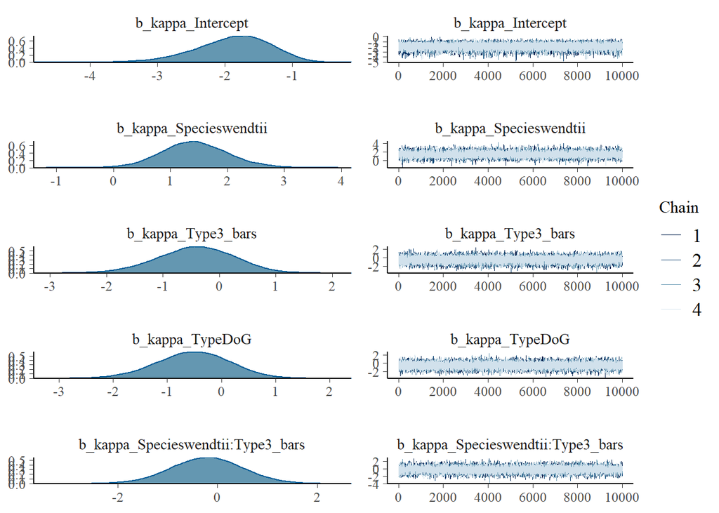

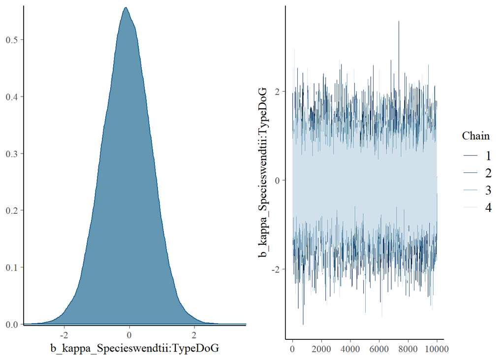

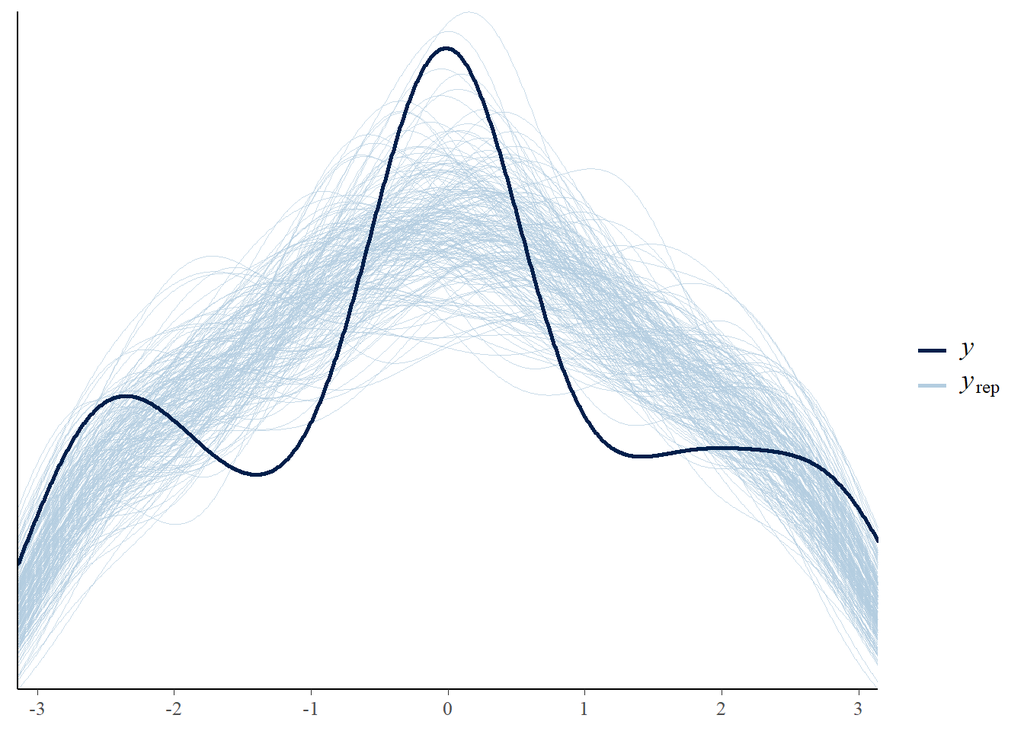

```r
pp_check(Mises_Both_Interaction.fit, type="dens_overlay", nsamples=200)
```

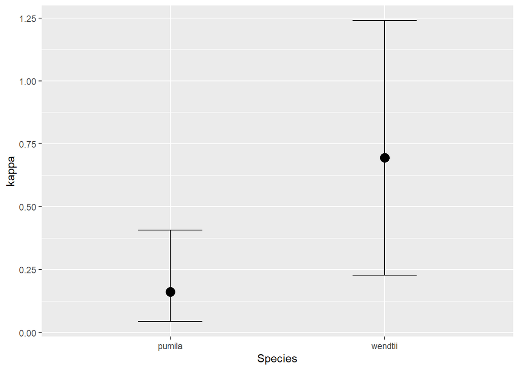

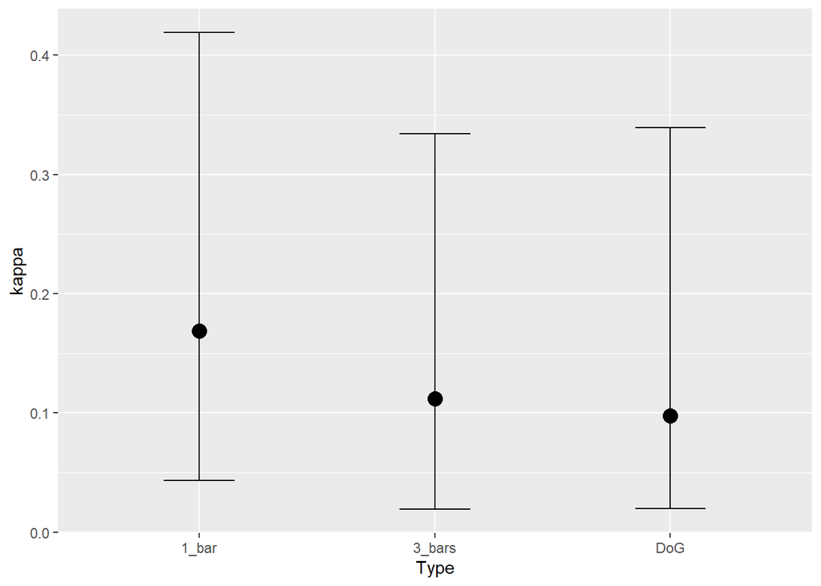

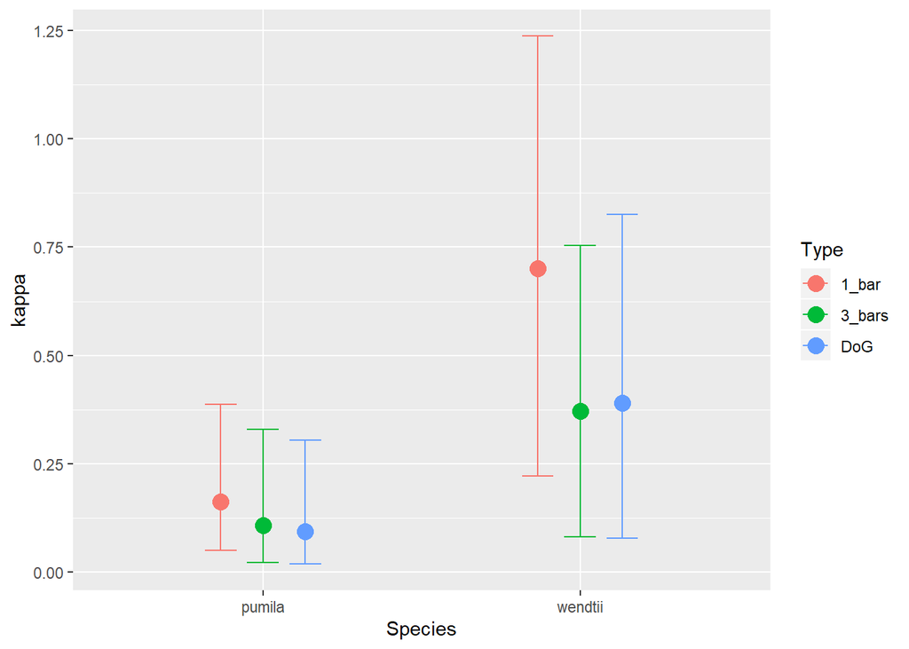

```r
marginal_effects(Mises_Both_Interaction.fit, method = c("fitted"),
                 dpar = "kappa", resolution = 1000, robust = TRUE,
                 theme=theme_classic(), nsamples = 1000, scale='response',
                                  re_formula = NULL, ask=F)
```

Compare the loo (leave-one-out cross validation) values of the various models.

```r
loo_compare(Mises_1_intercept.fit,Mises_Type.fit,Mises_Spp.fit,Mises_Both.fit,
            Mises_Both_Interaction.fit,criterion="loo")
```

```
##                            elpd_diff se_diff
## Mises_Spp.fit                0.0       0.0
## Mises_Both.fit              -0.7       1.2
## Mises_Both_Interaction.fit  -1.2       1.3
## Mises_Type.fit              -4.8       2.6
## Mises_1_intercept.fit      -42.5       9.7
```

Compare the waic (widely applicable information criterion) values of the various models.

```r
loo_compare(Mises_1_intercept.fit,Mises_Type.fit,Mises_Spp.fit,Mises_Both.fit,
            Mises_Both_Interaction.fit,criterion="waic")
```

```
##                            elpd_diff se_diff
## Mises_Spp.fit                0.0       0.0
## Mises_Both.fit              -0.7       1.2
## Mises_Both_Interaction.fit  -1.2       1.3
## Mises_Type.fit              -4.8       2.6
## Mises_1_intercept.fit      -42.5       9.7
```

The von Mises model with the effect of species is the best fit - *O. wendtii* is more oriented than *O. pumila* regardless of the stimulus.

## Full model with both effects and interaction

We interrogate with the model including both effects and their interaction and contrast the estimates of orientation with simulated data.

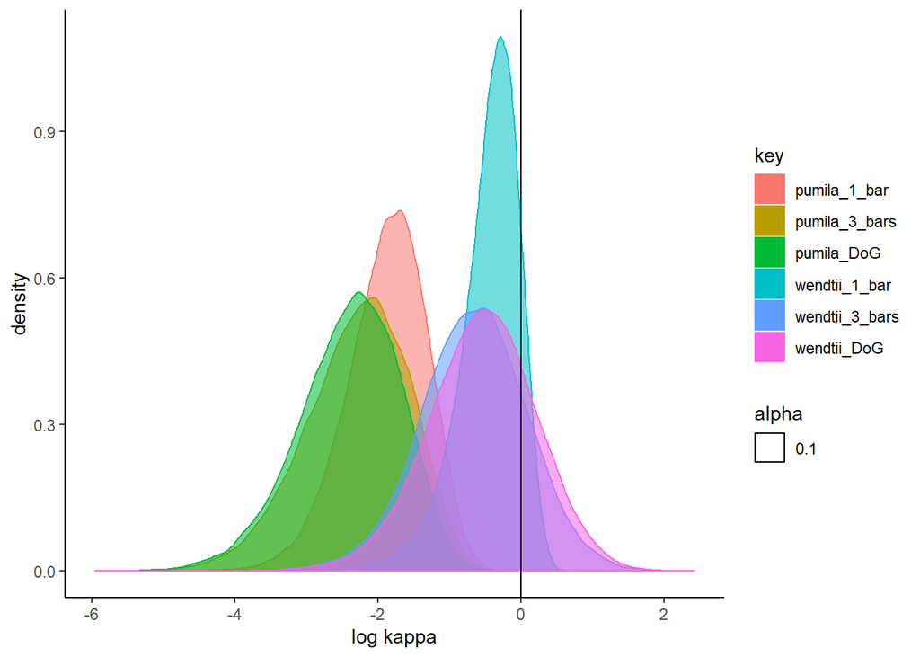

```r
Mises_Both_Interaction.post <- posterior_samples(Mises_Both_Interaction.fit)
Mises_Both_Interaction.post %>%
      mutate( pumila_1_bar = ((b_kappa_Intercept)),
            pumila_DoG = ((b_kappa_Intercept + b_kappa_TypeDoG)),
            pumila_3_bars   = ((b_kappa_Intercept + b_kappa_Type3_bars)),
            wendtii_1_bar   = ((b_kappa_Intercept + b_kappa_Specieswendtii)),
            wendtii_DoG  = (
              (b_kappa_Intercept + b_kappa_Specieswendtii +
                 `b_kappa_Specieswendtii:TypeDoG`)),
            wendtii_3_bars  =
            ((b_kappa_Intercept + b_kappa_Specieswendtii + `b_kappa_Specieswendtii:Type3_bars`))) %>%
            dplyr::select(-c(lp__,b_kappa_Intercept,b_kappa_TypeDoG,b_kappa_Type3_bars,b_kappa_Specieswendtii,`b_kappa_Specieswendtii:TypeDoG`,`b_kappa_Specieswendtii:Type3_bars`)) -> Mises_Both_Interaction.effects

Mises_Both_Interaction.effects %>% gather -> Mises_Both_Interaction.effects # df of exponentiated posteriors

Mises_Both_Interaction.effects %>%  mutate(value = A1(exp(value))) -> Mises_Both_Interaction.R

Mises_Both_Interaction.effects %>%
  ggplot(aes(x=value,group=key,color=key,fill=key,alpha=0.1)) + geom_density() + theme_classic() +
  geom_vline(xintercept=0) + xlab('log kappa')
```

Now, we plot the mean resultant length values.

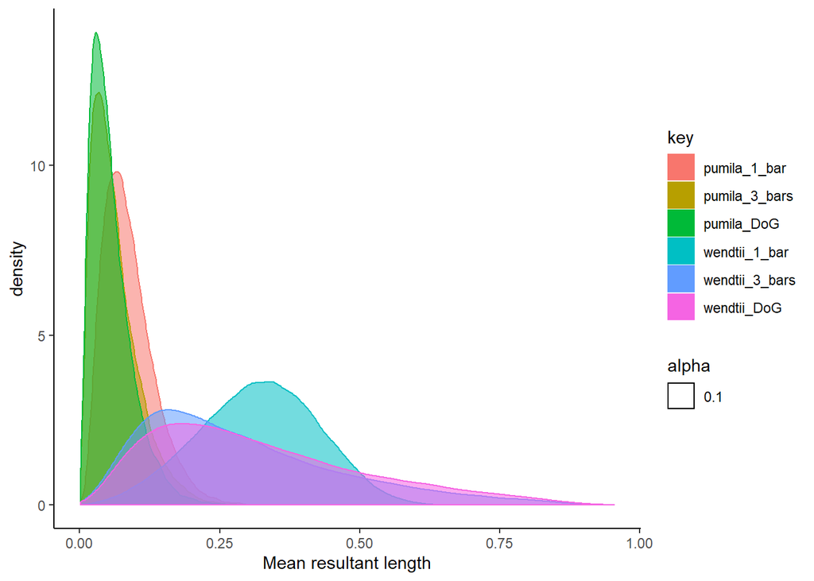

```r
Mises_Both_Interaction.R %>%
  ggplot(aes(x=value,group=key,color=key,fill=key,alpha=0.1)) + geom_density() + theme_classic() +
  xlab('Mean resultant length')
```

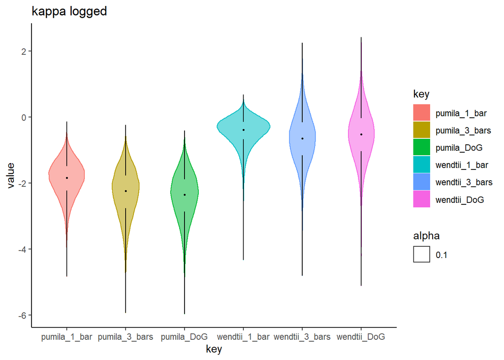

```r
library(ggthemes)
theme_set(theme_tufte())

Mises_Both_Interaction.effects %>%
  ggplot(aes(key,value)) + geom_violin(aes(color=key,fill=key,alpha=0.1)) + geom_tufteboxplot()  +
  theme_classic() + labs(title = "kappa logged")
```

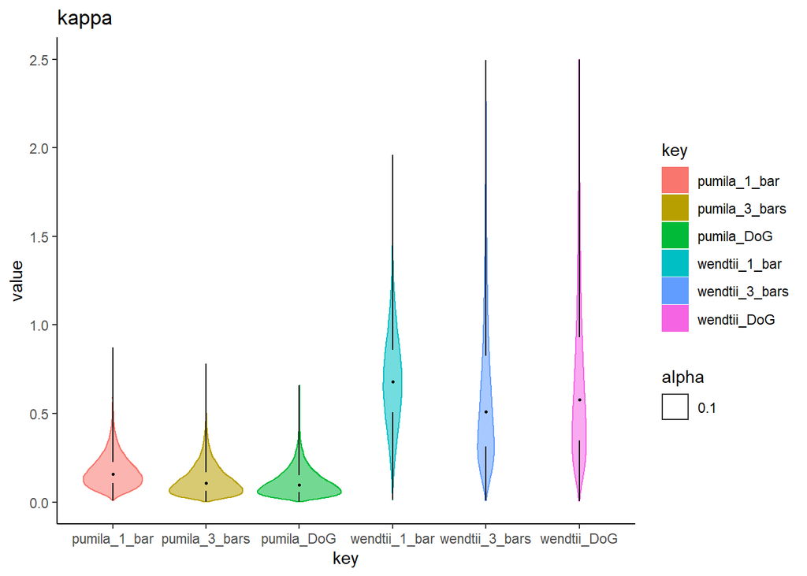

```r
Mises_Both_Interaction.effects %>% mutate(value = exp(value)) %>%
  ggplot(aes(key,value)) + geom_violin(aes(color=key,fill=key,alpha=0.1)) + geom_tufteboxplot()  +
  theme_classic() + ylim(0,2.5) + labs(title = "kappa")
```

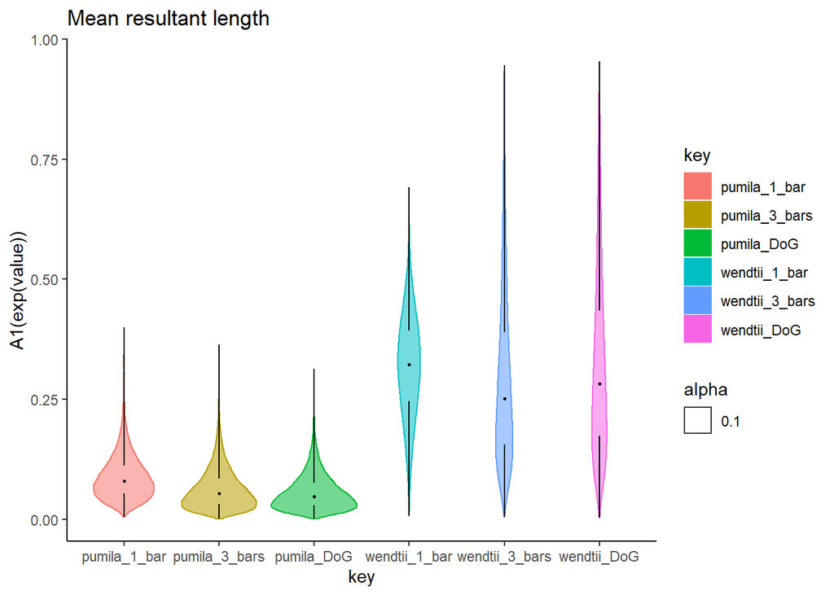

```r
Mises_Both_Interaction.effects %>%
  ggplot(aes(key,A1(exp(value)))) + geom_violin(aes(color=key,fill=key,alpha=0.1)) + geom_tufteboxplot()  + theme_classic() + labs(title = "Mean resultant length")
```

Exactly zero, in both cases, is theoretically uniform but what we expect from a random sample of 40 observations? We can check with some simple simulation.

```r
test1 <- rvon_mises(40,0,0)
test1 <- tibble(heading = test1)
test1.formula <- bf(heading ~ 0, kappa ~ 1, family = von_mises(link='tan_half') )
test1.prior = c(prior(normal(0, 3),  class = Intercept, dpar="kappa"))

test1.fit <- brm( test1.formula, prior = test1.prior, iter = 20000,
  data = test1, chains = 4, control = list(adapt_delta = 0.99999))
test1.fit <- add_criterion(test1.fit, c("loo","waic"))
summary(test1.fit)
```

```
##  Family: von_mises
##   Links: mu = tan_half; kappa = log
## Formula: heading ~ 0
##          kappa ~ 1
##    Data: test1 (Number of observations: 40)
## Samples: 4 chains, each with iter = 20000; warmup = 10000; thin = 1;
##          total post-warmup samples = 40000
##
## Population-Level Effects:
##                 Estimate Est.Error l-95% CI u-95% CI Rhat Bulk_ESS
## kappa_Intercept    -3.05      1.62    -6.98    -0.83 1.00     5719
##                 Tail_ESS
## kappa_Intercept     7419
##
## Samples were drawn using sampling(NUTS). For each parameter, Eff.Sample
## is a crude measure of effective sample size, and Rhat is the potential
## scale reduction factor on split chains (at convergence, Rhat = 1).
```

```r
log.kappa.simulations <- posterior_samples(test1.fit)
log.kappa.simulations <- log.kappa.simulations$b_kappa_Intercept
```

Contrasts between the conditions and simulated random data.

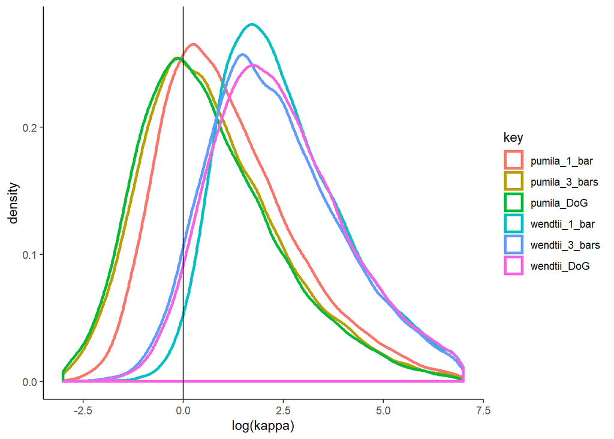

```r
Mises_Both_Interaction.post %>%
  mutate( pumila_1_bar = b_kappa_Intercept - log.kappa.simulations,
    pumila_DoG     = b_kappa_Intercept + b_kappa_TypeDoG - log.kappa.simulations,
    pumila_3_bars  = b_kappa_Intercept + b_kappa_Type3_bars - log.kappa.simulations,
    wendtii_1_bar  = b_kappa_Intercept + b_kappa_Specieswendtii - log.kappa.simulations,
    wendtii_DoG    = b_kappa_Intercept + b_kappa_Specieswendtii +
           `b_kappa_Specieswendtii:TypeDoG` - log.kappa.simulations,
            wendtii_3_bars = b_kappa_Intercept + b_kappa_Specieswendtii +
            `b_kappa_Specieswendtii:Type3_bars` - log.kappa.simulations) %>%
    dplyr::select(-c(lp__,b_kappa_Intercept,b_kappa_TypeDoG,b_kappa_Type3_bars,
                     b_kappa_Specieswendtii,`b_kappa_Specieswendtii:TypeDoG`,
                     `b_kappa_Specieswendtii:Type3_bars`)) %>% gather -> Mises_Both_Interaction.contrasts

Mises_Both_Interaction.contrasts  %>%
  ggplot(aes(x=value,group=key,color=key)) + geom_density(size=1.2) + theme_classic() +
  geom_vline(xintercept=0) + xlab('log(kappa)') + xlim(-3,7)
```

```r
Mises_Both_Interaction.contrasts %>% group_by(key) %>%
      summarise(Proportion = sumlength(value)) -> Overlap
Overlap
```

```
## # A tibble: 6 x 2
##   key            Proportion
##   <chr>               <dbl>
## 1 pumila_1_bar         27.1
## 2 pumila_3_bars        38.2
## 3 pumila_DoG           40.7
## 4 wendtii_1_bar         2
## 5 wendtii_3_bars        6
## 6 wendtii_DoG           5
```

Percentage overlap with simulated random data(above).

For all stimulus types, *O. wendtii* is highly unlikely to have the same orientedness or lower than the random simulated data - whereas, *O. pumila* has a much greater probability of being disoriented for all three stimulus types, especially the continuous visual stimulus (DoG).

# 2019 experiments with *Ophiocoma wendtii* in differing diel and light-adaptation conditions

The code below fits the model.

```r
Mises_Diel_1_intercept.formula <- bf(
  heading ~ 0, kappa ~ 1, family = von_mises(link='tan_half'))

Mises_Diel_1_intercept.prior = c(prior(normal(0,1),  class = Intercept, dpar="kappa"))

Mises_Diel_1_intercept.fit <- brm( Mises_Diel_1_intercept.formula,
  prior = Mises_Diel_1_intercept.prior, iter = 20000,
  data = df2019, chains = 4,
  control = list(adapt_delta = 0.9))
Mises_Diel_1_intercept.fit <- add_criterion(Mises_Diel_1_intercept.fit, c("loo","waic"))
```

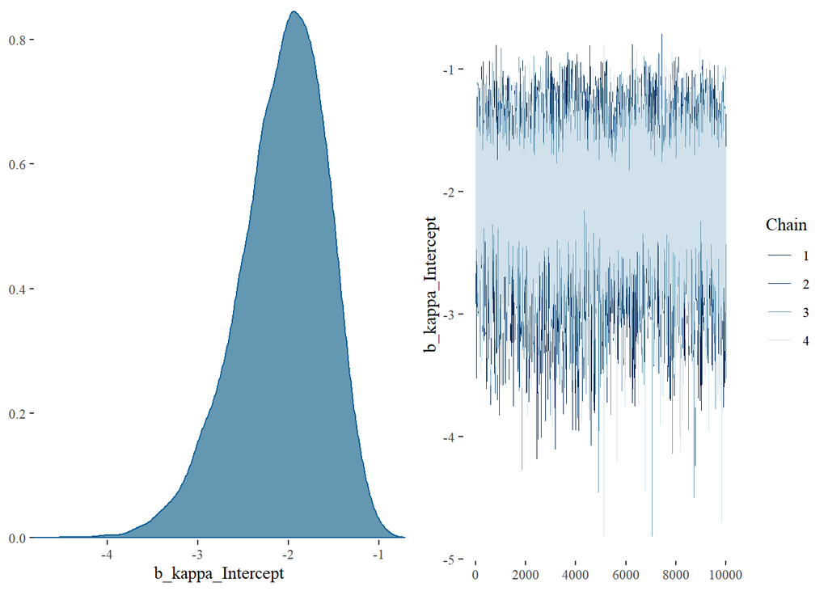

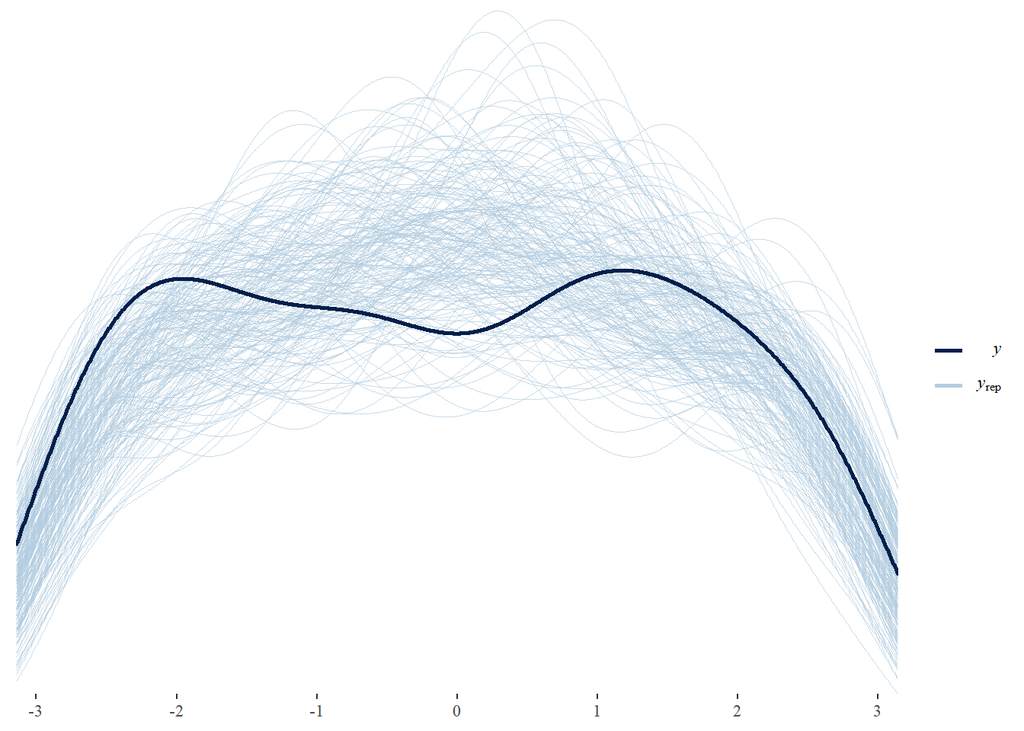

```r
pp_check(Mises_Diel_1_intercept.fit, type="dens_overlay", nsamples=200)
```

To interpret these, we can extract the values and reverse the log-link.

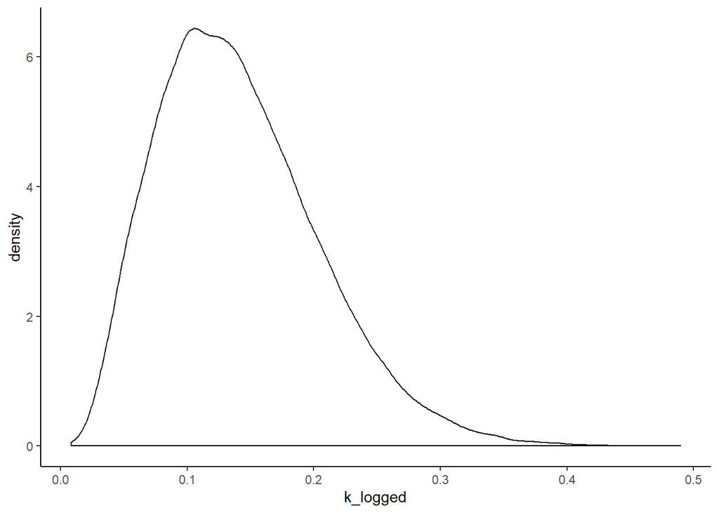

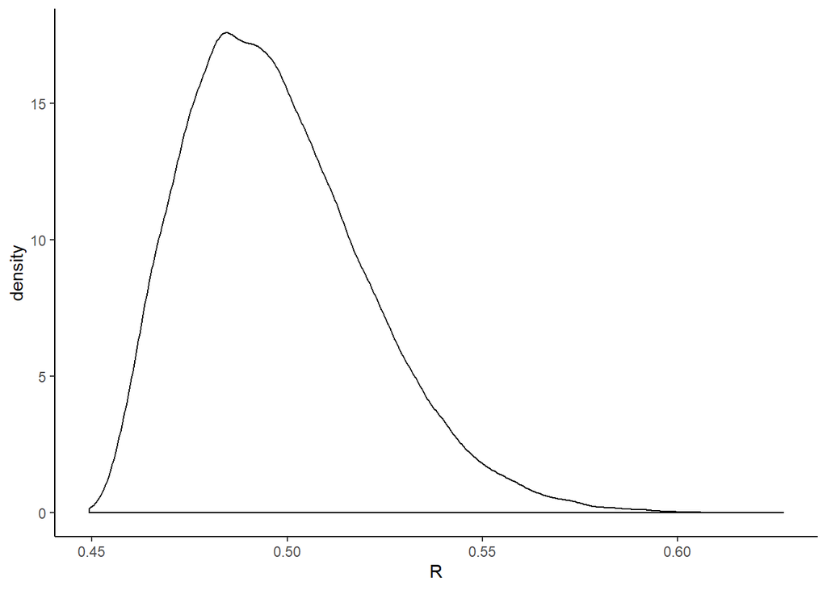

```
## recompiling to avoid crashing R session
```

```
##  Family: von_mises
##   Links: mu = tan_half; kappa = log
## Formula: heading ~ 0
##          kappa ~ Period_adaptation
##    Data: df2019 (Number of observations: 164)
## Samples: 4 chains, each with iter = 20000; warmup = 10000; thin = 1;
##          total post-warmup samples = 40000
##
## Population-Level Effects:
##                                    Estimate Est.Error l-95% CI u-95% CI
## kappa_Intercept                       -2.20      0.64    -3.56    -1.07
## kappa_Period_adaptationday_dark        0.22      0.82    -1.46     1.75
## kappa_Period_adaptationnight_dark     -0.42      0.80    -2.03     1.11
## kappa_Period_adaptationnight_light     0.12      0.79    -1.49     1.62
##                                    Rhat Bulk_ESS Tail_ESS
## kappa_Intercept                    1.00    26345    23436
## kappa_Period_adaptationday_dark    1.00    29517    26321
## kappa_Period_adaptationnight_dark  1.00    32337    26801
## kappa_Period_adaptationnight_light 1.00    29723    26379
##
## Samples were drawn using sampling(NUTS). For each parameter, Eff.Sample
## is a crude measure of effective sample size, and Rhat is the potential
## scale reduction factor on split chains (at convergence, Rhat = 1).
```

Plot the Markov chains and posterior probabilities.

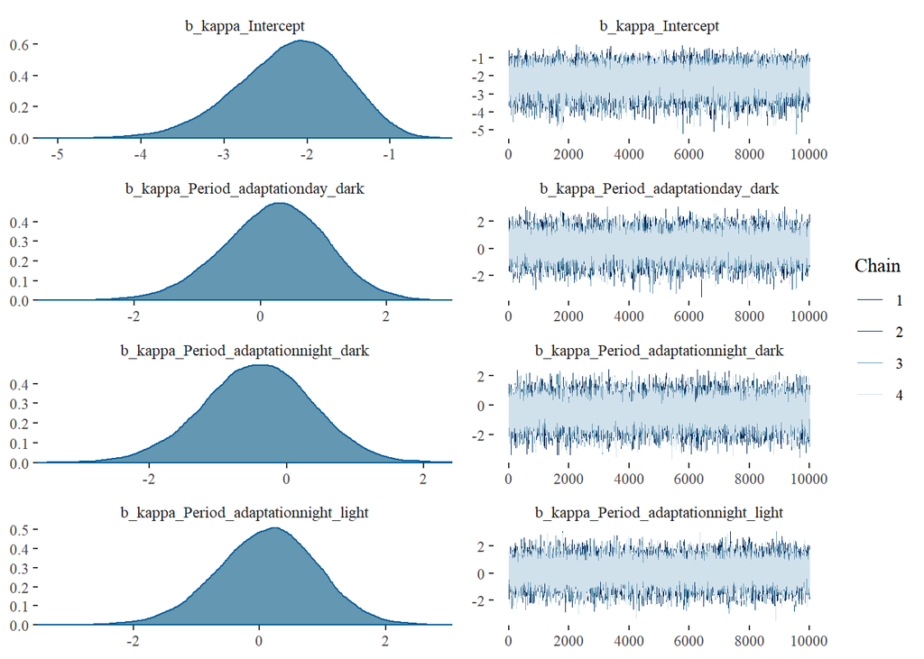

```r
plot(Mises_Diel_Period_adaptation.fit,ask=F)
```

Marginal effects at the median.

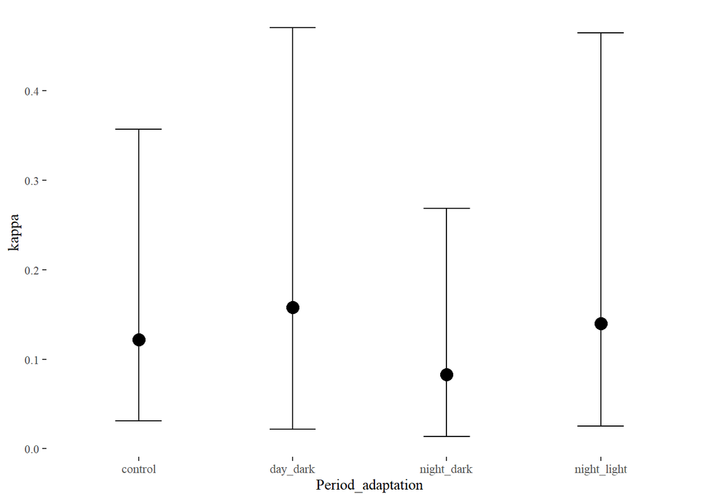

```r
marginal_effects(Mises_Diel_Period_adaptation.fit,method = "fitted",dpar = "kappa", resolution = 1000, robust = TRUE,
                 theme=theme_classic(), nsamples = 1000, scale='response',
                                  re_formula = NULL)
```

The night_dark treatment has a lowe kappa estimate as there is not orientation towards the stimulus.